# Project Three: Simple Linear Regression and Multiple Regression

You are a data analyst for a basketball team and have access to a large set of historical data that you can use to analyze performance patterns. The coach of the team and your management have requested that you come up with regression models that predict the total number of wins for a team in the regular season based on key performance metrics. Although the data set is the same that you used in the previous projects, the data set used here has been aggregated to study the total number of wins in a regular season based on performance metrics shown in the table below. These regression models will help make key decisions to improve the performance of the team. You will use the Python programming language to perform the statistical analyses and then prepare a report of your findings to present for the team’s management. Since the managers are not data analysts, you will need to interpret your findings and describe their practical implications.

There are four important variables in the data set that you will utilize in Project Three.

| Variable | What does it represent |
| --- | --- |
| total_wins | Total number of wins in a regular season |
| avg_pts | Average points scored in a regular season |
| avg_elo_n | Average relative skill of each team in a regular season |
| avg_pts_differential | Average point differential between the team and their opponents in a regular season |

The average relative skill (represented by the variable **avg_elo_n** in the data set) is simply the average of a team's relative skill in a regular season. Relative skill is measured using the ELO rating. This measure is inferred based on the final score of a game, the game location, and the outcome of the game relative to the probability of that outcome. The higher the number, the higher the relative skill of a team.

Reminder: It may be beneficial to review the summary report document for Project Three prior to starting this Python script. That will give you an idea of the questions you will need to answer with the outputs of this script.

## Step 1: Data Preparation

This step uploads the data set from a CSV file and transforms the data into a form that will be used to create regression models. The data will be aggregated to calculate the number of wins for teams in a basketball regular season between the years 1995 and 2015.

```python
import numpy as np
import pandas as pd
import scipy.stats as st
import matplotlib.pyplot as plt
from IPython.display import display, HTML

# dataframe for this project
nba_wins_df = pd.read_csv('nba_wins_data.csv')

display(HTML(nba_wins_df.head().to_html()))
print("printed only the first five observations...")
print("Number of rows in the dataset =", len(nba_wins_df))
```

|  | year_id | fran_id | avg_pts | avg_opp_pts | avg_elo_n | avg_opp_elo_n | avg_pts_differential | avg_elo_differential | total_wins |
| --- | --- | --- | --- | --- | --- | --- | --- | --- | --- |
| 0 | 1995 | Bucks | 99.341463 | 103.707317 | 1368.604789 | 1497.311587 | -4.365854 | -128.706798 | 34 |
| 1 | 1995 | Bulls | 101.524390 | 96.695122 | 1569.892129 | 1488.199352 | 4.829268 | 81.692777 | 47 |
| 2 | 1995 | Cavaliers | 90.451220 | 89.829268 | 1542.433391 | 1498.848261 | 0.621951 | 43.585130 | 43 |
| 3 | 1995 | Celtics | 102.780488 | 104.658537 | 1431.307532 | 1495.936224 | -1.878049 | -64.628693 | 35 |
| 4 | 1995 | Clippers | 96.670732 | 105.829268 | 1309.053701 | 1517.260260 | -9.158537 | -208.206558 | 17 |

```
printed only the first five observations...
Number of rows in the dataset = 618
```

## Step 2: Scatterplot and Correlation for the Total Number of Wins and Average Points Scored

Your coach expects teams to win more games in a regular season if they have a high average number of points compared to their opponents. This is because the chances of winning are higher if a team scores high in its games. Therefore, it is expected that the total number of wins and the average points scored are correlated. Calculate the Pearson correlation coefficient and its P-value.

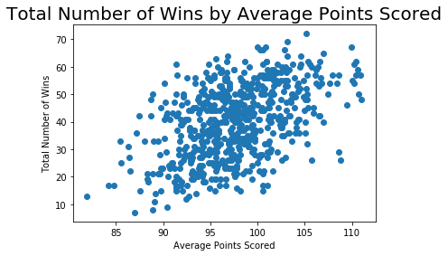

```
Correlation between Average Points Scored and the Total Number of Wins
Pearson Correlation Coefficient = 0.4777
P-value = 0.0
```

```python
import scipy.stats as st

plt.plot(nba_wins_df['avg_pts'], nba_wins_df['total_wins'], 'o')

plt.title('Total Number of Wins by Average Points Scored', fontsize=20)
plt.xlabel('Average Points Scored')
plt.ylabel('Total Number of Wins')
plt.show()


correlation_coefficient, p_value = st.pearsonr(nba_wins_df['avg_pts'], nba_wins_df['total_wins'])

print("Correlation between Average Points Scored and the Total Number of Wins ")
print("Pearson Correlation Coefficient =",  round(correlation_coefficient,4))
print("P-value =", round(p_value,4))
```

## Step 3: Simple Linear Regression: Predicting the Total Number of Wins using Average Points Scored

The coach of your team suggests a simple linear regression model with the total number of wins as the response variable and the average points scored as the predictor variable. He expects a team to have more wins in a season if it scores a high average points during that season. This regression model will help your coach predict how many games your team might win in a regular season if they maintain a certain average score. Create this simple linear regression model.

```python
import statsmodels.formula.api as smf

# Simple Linear Regression
model1 = smf.ols('total_wins ~ avg_pts', nba_wins_df).fit()
print(model1.summary())
```

```
                            OLS Regression Results
==============================================================================
Dep. Variable:             total_wins   R-squared:                       0.228
Model:                            OLS   Adj. R-squared:                  0.227
Method:                 Least Squares   F-statistic:                     182.1
Date:                Wed, 21 Oct 2020   Prob (F-statistic):           1.52e-36
Time:                        03:57:51   Log-Likelihood:                -2385.4
No. Observations:                 618   AIC:                             4775.
Df Residuals:                     616   BIC:                             4784.
Df Model:                           1
Covariance Type:            nonrobust
==============================================================================
                 coef    std err          t      P>|t|      [0.025      0.975]
------------------------------------------------------------------------------
Intercept    -85.5476      9.305     -9.194      0.000    -103.820     -67.275
avg_pts        1.2849      0.095     13.495      0.000       1.098       1.472
==============================================================================
Omnibus:                       24.401   Durbin-Watson:                   1.768
Prob(Omnibus):                  0.000   Jarque-Bera (JB):               11.089
Skew:                          -0.033   Prob(JB):                      0.00391
Kurtosis:                       2.347   Cond. No.                     1.97e+03
==============================================================================

Warnings:
[1] Standard Errors assume that the covariance matrix of the errors is correctly specified.
[2] The condition number is large, 1.97e+03. This might indicate that there are
strong multicollinearity or other numerical problems.
```

## Step 4: Scatterplot and Correlation for the Total Number of Wins and Average Relative Skill

Your management expects the team to win more games in the regular season if it maintains a high average relative skill compared to other teams. Therefore, it is expected that the total number of wins and the average relative skill are correlated. Calculate the Pearson correlation coefficient and its P-value.

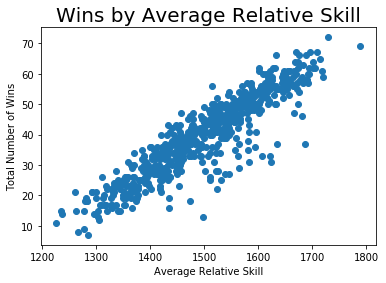

```
Correlation between Average Relative Skill and Total Number of Wins
Pearson Correlation Coefficient = 0.9072
P-value = 0.0
```

```python
plt.plot(nba_wins_df['avg_elo_n'], nba_wins_df['total_wins'], 'o')

plt.title('Wins by Average Relative Skill', fontsize=20)
plt.xlabel('Average Relative Skill')
plt.ylabel('Total Number of Wins')
plt.show()

correlation_coefficient, p_value = st.pearsonr(nba_wins_df['avg_elo_n'], nba_wins_df['total_wins'])

print("Correlation between Average Relative Skill and Total Number of Wins ")
print("Pearson Correlation Coefficient =",  round(correlation_coefficient,4))
print("P-value =", round(p_value,4))
```

## Step 5: Multiple Regression: Predicting the Total Number of Wins using Average Points Scored and Average Relative Skill

Instead of presenting a simple linear regression model to the coach, you can suggest a multiple regression model with the total number of wins as the response variable and the average points scored and the average relative skill as predictor variables. This regression model will help your coach predict how many games your team might win in a regular season based on metrics like the average points scored and average relative skill. This model is more practical because you expect more than one performance metric to determine the total number of wins in a regular season. Create this multiple regression model.

```python
import statsmodels.formula.api as smf

# Multiple Regression
model2 = smf.ols('total_wins ~ avg_pts + avg_elo_n', nba_wins_df).fit()
print(model2.summary())
```

```
                            OLS Regression Results
==============================================================================
Dep. Variable:             total_wins   R-squared:                       0.837
Model:                            OLS   Adj. R-squared:                  0.837
Method:                 Least Squares   F-statistic:                     1580.
Date:                Wed, 21 Oct 2020   Prob (F-statistic):          4.41e-243
Time:                        04:07:37   Log-Likelihood:                -1904.6
No. Observations:                 618   AIC:                             3815.
Df Residuals:                     615   BIC:                             3829.
Df Model:                           2
Covariance Type:            nonrobust
==============================================================================
                 coef    std err          t      P>|t|      [0.025      0.975]
------------------------------------------------------------------------------
Intercept   -152.5736      4.500    -33.903      0.000    -161.411    -143.736
avg_pts        0.3497      0.048      7.297      0.000       0.256       0.444
avg_elo_n      0.1055      0.002     47.952      0.000       0.101       0.110
==============================================================================
Omnibus:                       89.087   Durbin-Watson:                   1.203
Prob(Omnibus):                  0.000   Jarque-Bera (JB):              160.540
Skew:                          -0.869   Prob(JB):                     1.38e-35
Kurtosis:                       4.793   Cond. No.                     3.19e+04
==============================================================================

Warnings:
[1] Standard Errors assume that the covariance matrix of the errors is correctly specified.
[2] The condition number is large, 3.19e+04. This might indicate that there are
strong multicollinearity or other numerical problems.
```

## Step 6: Multiple Regression: Predicting the Total Number of Wins using Average Points Scored, Average Relative Skill, and Average Points Differential

The coach also wants you to consider the average points differential as a predictor variable in the multiple regression model. Create a multiple regression model with the total number of wins as the response variable, and average points scored, average relative skill, and average points differential as predictor variables. This regression model will help your coach predict how many games your team might win in a regular season based on metrics like the average score, average relative skill, and the average points differential between the team and their opponents.

Use Step 5 to help you write this code block. Here is some information that will help you write this code block. Reach out to your instructor if you need help.

1. The dataframe used in this project is called nba_wins_df.
2. The variable **avg_pts** represents average points scored by each team in a regular season.
3. The variable **avg_elo_n** represents average relative skill of each team in a regular season.
4. The variable **avg_pts_differential** represents average points differential between each team and their opponents in a regular season.
5. Print the model summary.

```python
# Write your code in this code block section
import statsmodels.formula.api as smf

# Multiple Regression
model2 = smf.ols('total_wins ~ avg_pts + avg_elo_n + avg_pts_differential', nba_wins_df).fit()
print(model2.summary())
```

```
                            OLS Regression Results
==============================================================================
Dep. Variable:             total_wins   R-squared:                       0.876
Model:                            OLS   Adj. R-squared:                  0.876
Method:                 Least Squares   F-statistic:                     1449.
Date:                Wed, 21 Oct 2020   Prob (F-statistic):          5.03e-278
Time:                        04:14:59   Log-Likelihood:                -1819.8
No. Observations:                 618   AIC:                             3648.
Df Residuals:                     614   BIC:                             3665.
Df Model:                           3
Covariance Type:            nonrobust
========================================================================================
                           coef    std err          t      P>|t|      [0.025      0.975]
----------------------------------------------------------------------------------------
Intercept              -35.8921      9.252     -3.879      0.000     -54.062     -17.723
avg_pts                  0.2406      0.043      5.657      0.000       0.157       0.324
avg_elo_n                0.0348      0.005      6.421      0.000       0.024       0.045
avg_pts_differential     1.7621      0.127     13.928      0.000       1.514       2.011
==============================================================================
Omnibus:                      181.805   Durbin-Watson:                   0.975
Prob(Omnibus):                  0.000   Jarque-Bera (JB):              506.551
Skew:                          -1.452   Prob(JB):                    1.01e-110
Kurtosis:                       6.352   Cond. No.                     7.51e+04
==============================================================================

Warnings:
[1] Standard Errors assume that the covariance matrix of the errors is correctly specified.
[2] The condition number is large, 7.51e+04. This might indicate that there are
strong multicollinearity or other numerical problems.
```

## End of Project Three

Download the HTML output and submit it with your summary report for Project Three. The HTML output can be downloaded by clicking **File**, then **Download as**, then **HTML**. Do not include the Python code within your summary report.